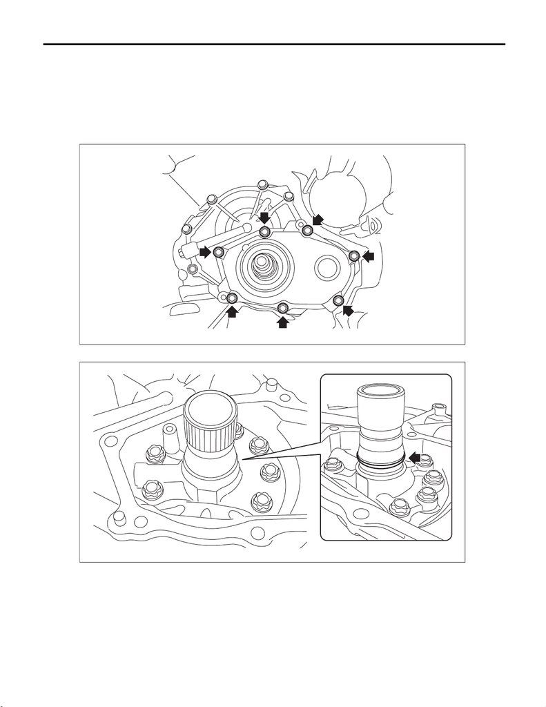

CVT(TR690)-285

Oil Pump Chain

CONTINUOUSLY VARIABLE TRANSMISSION

46.Oil Pump Chain

A: REMOVAL

1) Remove the transmission assembly from the vehicle. <Ref. to CVT(TR690)-56, REMOVAL, Automatic

Transmission Assembly.>

2) Remove the torque converter assembly. <Ref. to CVT(TR690)-140, REMOVAL, Torque Converter As-

sembly.>

3) Remove the oil pump chain cover.

4) Remove the seal ring from center support COMPL.

AT-05403

AT-05414

15WRX_STI_US_EN.book 285 ページ ２０１５年２月１３日 金曜日 午前１１時２０分

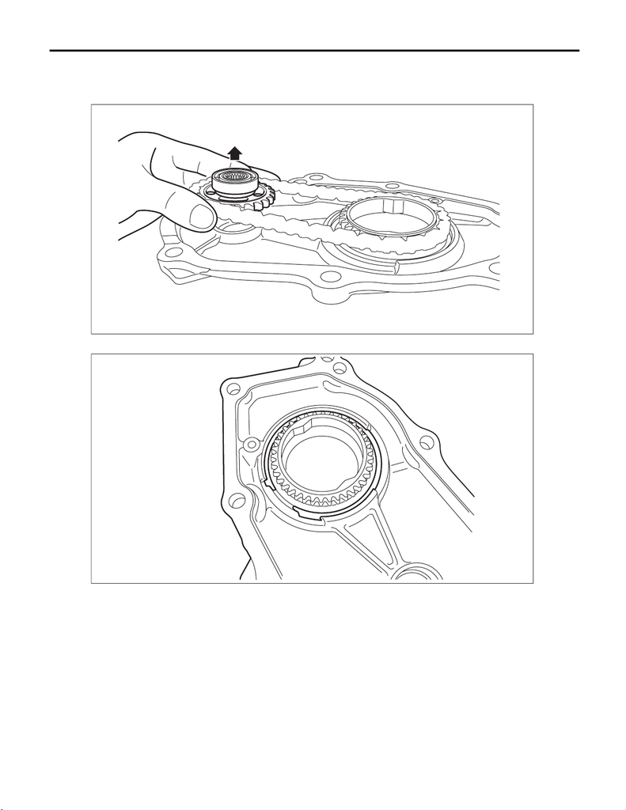

CVT(TR690)-286

Oil Pump Chain

CONTINUOUSLY VARIABLE TRANSMISSION

5) Remove the driven sprocket from oil pump chain cover to remove the oil pump chain.

NOTE:

The driven sprocket is replaced as an assembly only, because it is a non-disassembly part.

6) Remove the snap ring.

AT-05404

AT-05405

15WRX_STI_US_EN.book 286 ページ ２０１５年２月１３日 金曜日 午前１１時２０分

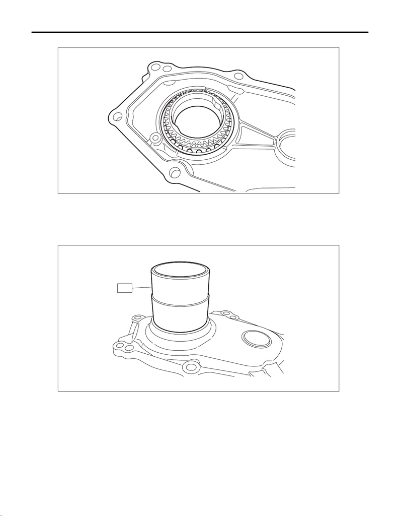

CVT(TR690)-287

Oil Pump Chain

CONTINUOUSLY VARIABLE TRANSMISSION

7) Remove the drive sprocket.

8) Remove the oil seal from the oil pump chain cover.

B: INSTALLATION

1) Clean the mating surface of oil pump chain cover and converter case cover.

2) Using the ST, install the oil seal.

ST 499755602 PRESS SNAP RING

AT-05406

AT-05407

ST

15WRX_STI_US_EN.book 287 ページ ２０１５年２月１３日 金曜日 午前１１時２０分

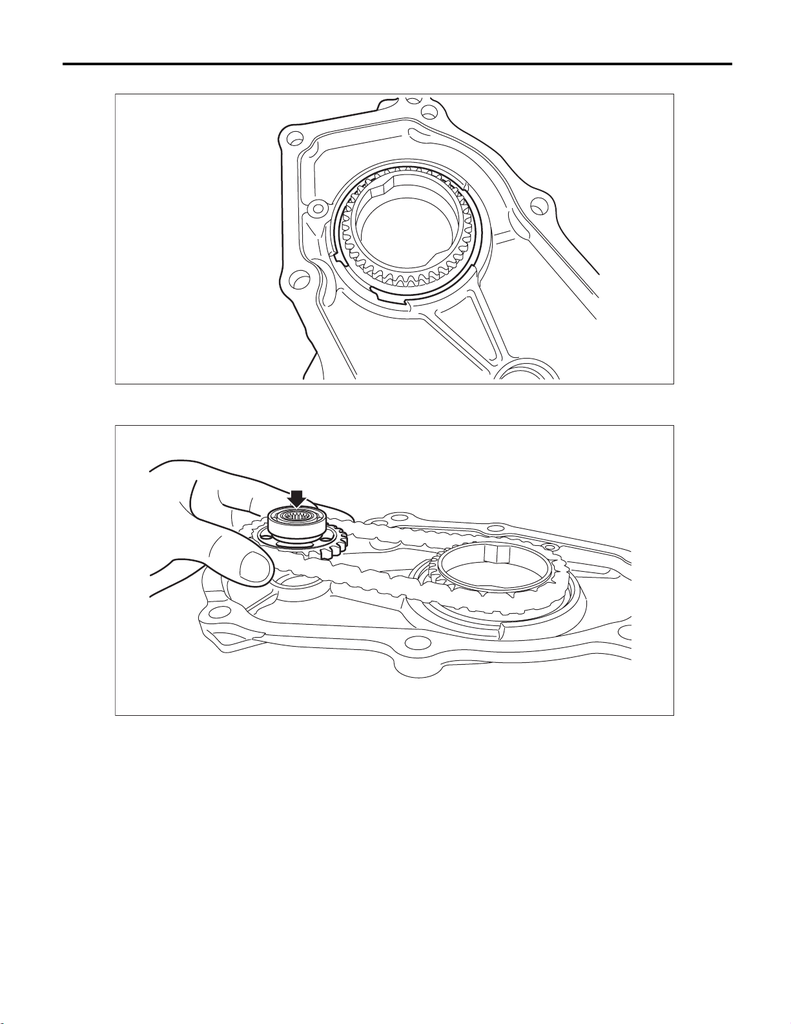

CVT(TR690)-288

Oil Pump Chain

CONTINUOUSLY VARIABLE TRANSMISSION

3) Install the drive sprocket and install the snap ring.

4) Place the oil pump chain on drive sprocket.

5) Place the oil pump chain on driven sprocket and install the driven sprocket to oil pump chain cover.

AT-05405

AT-05408

15WRX_STI_US_EN.book 288 ページ ２０１５年２月１３日 金曜日 午前１１時２０分

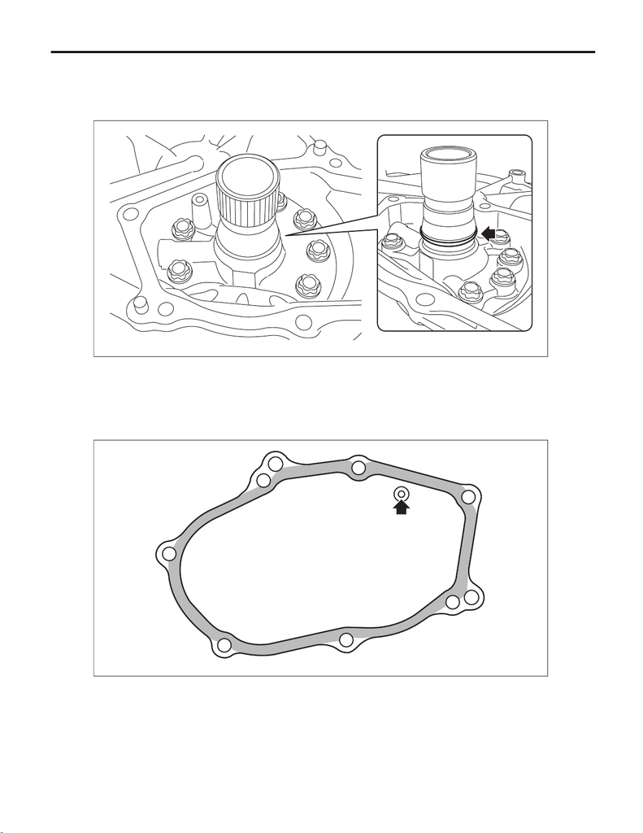

CVT(TR690)-289

Oil Pump Chain

CONTINUOUSLY VARIABLE TRANSMISSION

6) Install the seal ring to center support COMPL.

NOTE:

• Use new seal rings.

• Apply CVTF to the seal rings.

7) Apply liquid gasket seamlessly to the mating surface of oil pump chain cover.

CAUTION:

Do not apply liquid gasket at the arrowed hole.

Liquid gasket:

THREE BOND 1215B or equivalent

AT-05414

AT-05409

15WRX_STI_US_EN.book 289 ページ ２０１５年２月１３日 金曜日 午前１１時２０分

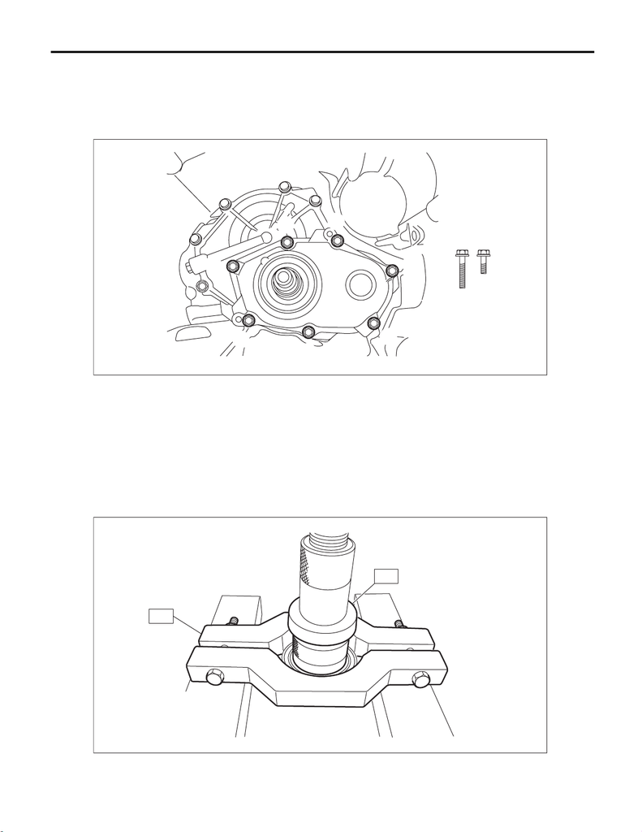

CVT(TR690)-290

Oil Pump Chain

CONTINUOUSLY VARIABLE TRANSMISSION

8) Install the oil pump chain cover.

NOTE:

There are two types of bolt.

Tightening torque:

24 N·m (2.4 kgf-m, 17.7 ft-lb)

9) Install the torque converter assembly. <Ref. to CVT(TR690)-141, INSTALLATION, Torque Converter As-

sembly.>

10) Install the transmission assembly to the vehicle. <Ref. to CVT(TR690)-69, INSTALLATION, Automatic

Transmission Assembly.>

C: DISASSEMBLY

1. DRIVE SPROCKET

1) Remove the ball bearing using ST.

ST1 498077600 REMOVER

ST2 399513600 INSTALLER

AT-05410

(A)

(A)

(B)

(B)

(B) (A)

(B)

(B)

(B)

AT-05411

ST1

ST2

15WRX_STI_US_EN.book 290 ページ ２０１５年２月１３日 金曜日 午前１１時２０分

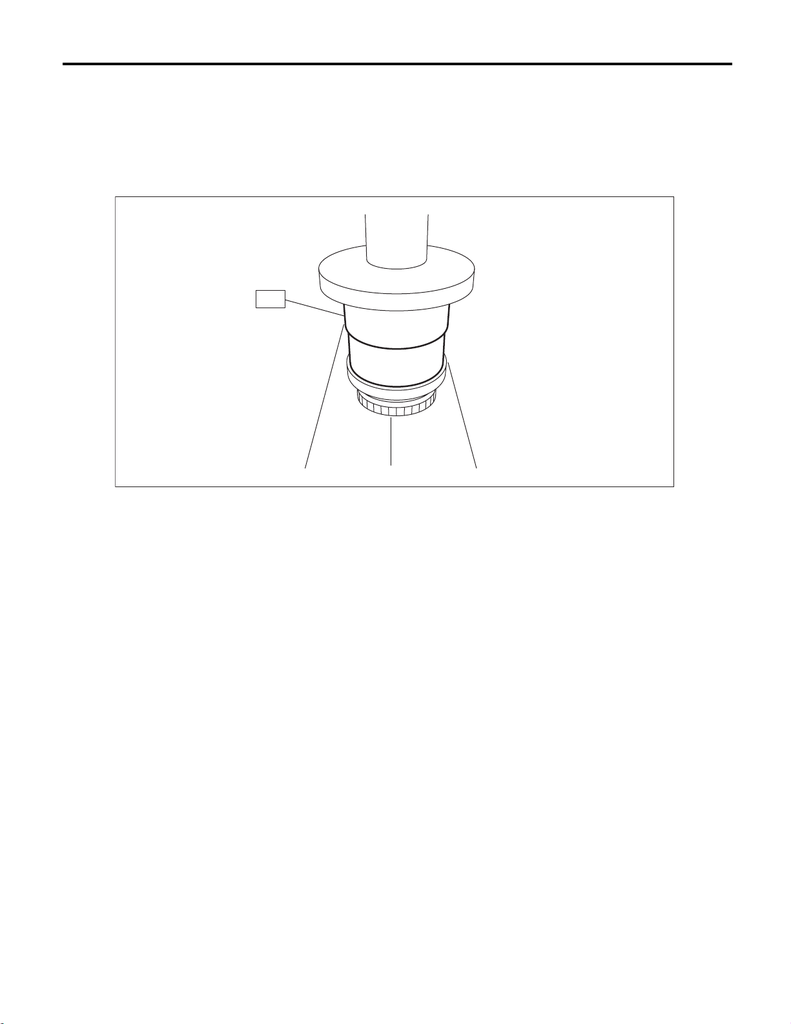

CVT(TR690)-291

Oil Pump Chain

CONTINUOUSLY VARIABLE TRANSMISSION

D: ASSEMBLY

1. DRIVE SPROCKET

1) Using the ST, install the ball bearing.

NOTE:

Use a new ball bearing.

ST 499755602 PRESS SNAP RING

E: INSPECTION

• Check the oil pump chain for damage.

• Replace if gear teeth are broken, damaged, sharpen or excessively worn.

• Check the bearing for seizure or wear.

• Apply CVTF to bearing and rotate the bearing to check for noise or dragging etc.

• Check the oil pump chain cover for damage.

• Check for leakage of CVTF from the mating surface of oil pump chain cover.

• Check the oil seal for damage.

AT-05412

ST

15WRX_STI_US_EN.book 291 ページ ２０１５年２月１３日 金曜日 午前１１時２０分